# The calibration search on the sraffian arm — the fit trajectory, and why fit is not stability

Seed 20260923, the full 500-draw run: the objective falls 0.809 → 0.0294 and then plateaus, while the debt bound that would make the baseline *stable* is never the thing being minimised.

Author

LEEDS_MODEL — JUST2CE

Published

September 28, 2026

**Written:** 2026-09-27 · **Repo at:** `main` @ `ea0b773` (this report only reads; the search runs detached).

**Read from:** the live `stderr` trace of the detached search (`/tmp/calib_search_gdp.log`), parsed into `qmd/reports/2026-09-27-calibration-search-evidence/trail.csv`. The search itself is `R/calibrate_random_search.R --arm sraffian --iters 500 --scale gdp --deflate --period 100` (default instruments: `taxes, propensities, markups`).

**Status of claims:** every number below is recomputed in this document’s setup chunk from the parsed trace; nothing is typed by hand. The search ran to completion (500 draws, 11 accepted).

# 1. What is being minimised — and what is not

The scalar the search minimises is `calib_fitness` with `scale = "gdp"`, `deflate = TRUE`, scored at `period = 100`: the mean squared deviation of the 24 target cells (12 concepts × 2 regions), each deviation expressed as a fraction of the region’s value-added target. A draw is accepted only if it improves that scalar **and** the run completes all 100 periods.

Two things the scalar does **not** see, both relevant to the stability question:

- It is a **point snapshot** at t = 100, so a config whose debt/GDP happens to pass through the target at t = 100 while still diverging after it scores well.
- It does **not** contain the debt bound (`min_t b_s > 0` and `mean_t(b_s[t]/b_s[t-1] − 1) ≤ g`), which is what “stable baseline” actually means. That bound is reported separately, and — for this seed — can never be met, because `rates` is not an instrument and `rb = r_star + mu_b` stays pinned at ~2.16% against `g ≈ 1%`, so `(1+rb)/(1+g) > 1` throughout.

So the trajectory below is the **fit** path. The stability path is the 8 `rates`-instrument seeds launched alongside, which do report the bound per draw.

# 2. The trajectory

The objective falls 0.8094 → 0.0294 across 500 draws (11 accepted), then plateaus — the last ~150 draws move the incumbent only in the 4th decimal.

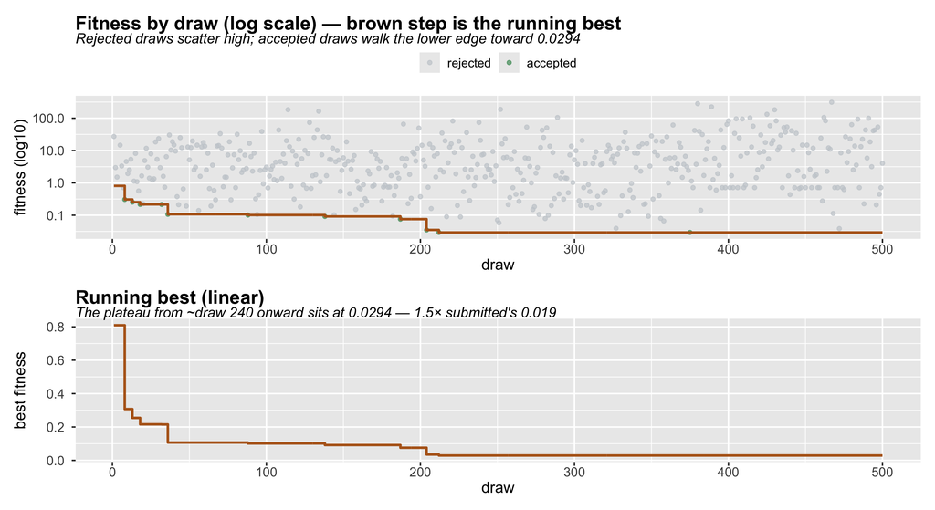

Figure 1

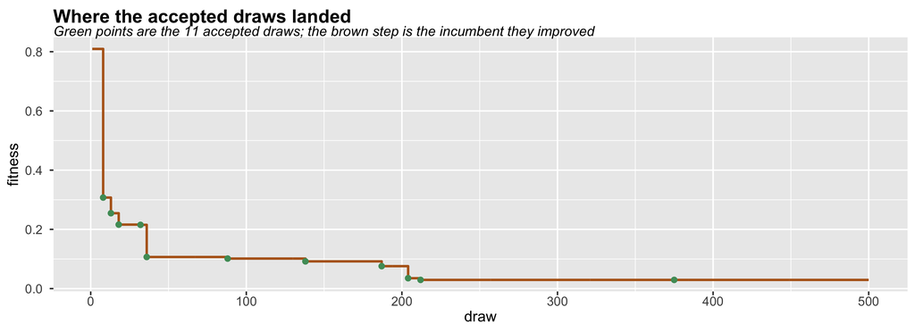

Figure 2

# 3. What the plateau means

The search has found the best **point-fit** its instrument set can reach — 0.0294 against the `submitted` reference of 0.019 and the `sraffian` starting point of 0.809. But because `rates` is absent, that config is still a *diverging* one: the debt bound is not in the objective and cannot be satisfied by the levers this seed is allowed to move. The plateau is the fit ceiling without stability, not a stable baseline.

The 8 seeds launched with `taxes, propensities, rates` are the experiment that decides whether the space contains a config that is both a good fit **and** stable; their per-draw `debt_grow`/`g` lines are the number this seed cannot produce.

**Sources:** `R/calibrate_random_search.R` · `R/calibration_2026.R` · `qmd/reports/2026-09-27-calibration-search-evidence/trail.csv` (parsed from the live search trace) · `log/NEXT_SESSION.md`